# Data Science, Artificial Intelligence, Machine Learning and Deep Learning:

Tips and tricks with R and Python

Akil Elkamel

6/11/2020

## pivot_longer() - Definition

The pivot_longer() function from the tidyr package, “lengthens” data, increasing the number of rows and decreasing the number of columns. The inverse transformation is pivot_wider()

**Usage:**

```r
pivot_longer(
  data,
  cols,
  names_to = "name",
  names_prefix = NULL,
  names_sep = NULL,
  names_pattern = NULL,
  names_ptypes = list(),
  names_transform = list(),
  names_repair = "check_unique",
  values_to = "value",
  values_drop_na = FALSE,
  values_ptypes = list(),
  values_transform = list(),
  ...
)
```

## pivot_longer() - Example 1

```r
# Simplest case where column names are character data
relig_income
```

```
## # A tibble: 18 x 11
##    religion `<$10k` `$10-20k` `$20-30k` `$30-40k` `$40-50k` `$50-75k` `$75-100k`
##    <chr>      <dbl>     <dbl>     <dbl>     <dbl>     <dbl>     <dbl>      <dbl>
##  1 Agnostic      27        34        60        81        76       137        122
##  2 Atheist       12        27        37        52        35        70         73
##  3 Buddhist      27        21        30        34        33        58         62
##  4 Catholic     418       617       732       670       638      1116        949
##  5 Don’t k~      15        14        15        11        10        35         21
##  6 Evangel~     575       869      1064       982       881      1486        949
##  7 Hindu          1         9         7         9        11        34         47
##  8 Histori~     228       244       236       238       197       223        131
##  9 Jehovah~      20        27        24        24        21        30         15
## 10 Jewish        19        19        25        25        30        95         69
## 11 Mainlin~     289       495       619       655       651      1107        939
## 12 Mormon        29        40        48        51        56       112         85
## 13 Muslim         6         7         9        10         9        23         16
## 14 Orthodox      13        17        23        32        32        47         38
## 15 Other C~       9         7        11        13        13        14         18
## 16 Other F~      20        33        40        46        49        63         46
## 17 Other W~       5         2         3         4         2         7          3
## 18 Unaffil~     217       299       374       365       341       528        407
## # ... with 3 more variables: `$100-150k` <dbl>, `>150k` <dbl>, `Don't
## #   know/refused` <dbl>
```

## pivot_longer() - Example 1

```r
relig_income %>%
  pivot_longer(-religion, names_to = "income", values_to = "count")
```

```
## # A tibble: 180 x 3
##    religion income             count
##    <chr>    <chr>              <dbl>
##  1 Agnostic <$10k                 27
##  2 Agnostic $10-20k               34
##  3 Agnostic $20-30k               60
##  4 Agnostic $30-40k               81
##  5 Agnostic $40-50k               76
##  6 Agnostic $50-75k              137
##  7 Agnostic $75-100k             122
##  8 Agnostic $100-150k            109
##  9 Agnostic >150k                 84
## 10 Agnostic Don't know/refused    96
## # ... with 170 more rows
```

## pivot_longer() - Example 2

```r
# Slightly more complex case where columns have common prefix,
# and missing missings are structural so should be dropped.
billboard
```

```
## # A tibble: 317 x 79
##    artist track date.entered   wk1   wk2   wk3   wk4   wk5   wk6   wk7   wk8
##    <chr>  <chr> <date>       <dbl> <dbl> <dbl> <dbl> <dbl> <dbl> <dbl> <dbl>
##  1 2 Pac  Baby~ 2000-02-26      87    82    72    77    87    94    99    NA
##  2 2Ge+h~ The ~ 2000-09-02      91    87    92    NA    NA    NA    NA    NA
##  3 3 Doo~ Kryp~ 2000-04-08      81    70    68    67    66    57    54    53
##  4 3 Doo~ Loser 2000-10-21      76    76    72    69    67    65    55    59
##  5 504 B~ Wobb~ 2000-04-15      57    34    25    17    17    31    36    49
##  6 98^0   Give~ 2000-08-19      51    39    34    26    26    19     2     2
##  7 A*Tee~ Danc~ 2000-07-08      97    97    96    95   100    NA    NA    NA
##  8 Aaliy~ I Do~ 2000-01-29      84    62    51    41    38    35    35    38
##  9 Aaliy~ Try ~ 2000-03-18      59    53    38    28    21    18    16    14
## 10 Adams~ Open~ 2000-08-26      76    76    74    69    68    67    61    58
## # ... with 307 more rows, and 68 more variables: wk9 <dbl>, wk10 <dbl>,
## #   wk11 <dbl>, wk12 <dbl>, wk13 <dbl>, wk14 <dbl>, wk15 <dbl>, wk16 <dbl>,
## #   wk17 <dbl>, wk18 <dbl>, wk19 <dbl>, wk20 <dbl>, wk21 <dbl>, wk22 <dbl>,
## #   wk23 <dbl>, wk24 <dbl>, wk25 <dbl>, wk26 <dbl>, wk27 <dbl>, wk28 <dbl>,
## #   wk29 <dbl>, wk30 <dbl>, wk31 <dbl>, wk32 <dbl>, wk33 <dbl>, wk34 <dbl>,
## #   wk35 <dbl>, wk36 <dbl>, wk37 <dbl>, wk38 <dbl>, wk39 <dbl>, wk40 <dbl>,
## #   wk41 <dbl>, wk42 <dbl>, wk43 <dbl>, wk44 <dbl>, wk45 <dbl>, wk46 <dbl>,
## #   wk47 <dbl>, wk48 <dbl>, wk49 <dbl>, wk50 <dbl>, wk51 <dbl>, wk52 <dbl>,
## #   wk53 <dbl>, wk54 <dbl>, wk55 <dbl>, wk56 <dbl>, wk57 <dbl>, wk58 <dbl>,
## #   wk59 <dbl>, wk60 <dbl>, wk61 <dbl>, wk62 <dbl>, wk63 <dbl>, wk64 <dbl>,
## #   wk65 <dbl>, wk66 <lgl>, wk67 <lgl>, wk68 <lgl>, wk69 <lgl>, wk70 <lgl>,
## #   wk71 <lgl>, wk72 <lgl>, wk73 <lgl>, wk74 <lgl>, wk75 <lgl>, wk76 <lgl>
```

## pivot_longer() - Example 2

```r
# Slightly more complex case where columns have common prefix,
# and missing missings are structural so should be dropped.
billboard
```

```
## # A tibble: 317 x 79
##    artist track date.entered   wk1   wk2   wk3   wk4   wk5   wk6   wk7   wk8
##    <chr>  <chr> <date>       <dbl> <dbl> <dbl> <dbl> <dbl> <dbl> <dbl> <dbl>
##  1 2 Pac  Baby~ 2000-02-26      87    82    72    77    87    94    99    NA
##  2 2Ge+h~ The ~ 2000-09-02      91    87    92    NA    NA    NA    NA    NA
##  3 3 Doo~ Kryp~ 2000-04-08      81    70    68    67    66    57    54    53
##  4 3 Doo~ Loser 2000-10-21      76    76    72    69    67    65    55    59
##  5 504 B~ Wobb~ 2000-04-15      57    34    25    17    17    31    36    49
##  6 98^0   Give~ 2000-08-19      51    39    34    26    26    19     2     2
##  7 A*Tee~ Danc~ 2000-07-08      97    97    96    95   100    NA    NA    NA
##  8 Aaliy~ I Do~ 2000-01-29      84    62    51    41    38    35    35    38
##  9 Aaliy~ Try ~ 2000-03-18      59    53    38    28    21    18    16    14
## 10 Adams~ Open~ 2000-08-26      76    76    74    69    68    67    61    58
## # ... with 307 more rows, and 68 more variables: wk9 <dbl>, wk10 <dbl>,
## #   wk11 <dbl>, wk12 <dbl>, wk13 <dbl>, wk14 <dbl>, wk15 <dbl>, wk16 <dbl>,
## #   wk17 <dbl>, wk18 <dbl>, wk19 <dbl>, wk20 <dbl>, wk21 <dbl>, wk22 <dbl>,
## #   wk23 <dbl>, wk24 <dbl>, wk25 <dbl>, wk26 <dbl>, wk27 <dbl>, wk28 <dbl>,
## #   wk29 <dbl>, wk30 <dbl>, wk31 <dbl>, wk32 <dbl>, wk33 <dbl>, wk34 <dbl>,
## #   wk35 <dbl>, wk36 <dbl>, wk37 <dbl>, wk38 <dbl>, wk39 <dbl>, wk40 <dbl>,
## #   wk41 <dbl>, wk42 <dbl>, wk43 <dbl>, wk44 <dbl>, wk45 <dbl>, wk46 <dbl>,
## #   wk47 <dbl>, wk48 <dbl>, wk49 <dbl>, wk50 <dbl>, wk51 <dbl>, wk52 <dbl>,
## #   wk53 <dbl>, wk54 <dbl>, wk55 <dbl>, wk56 <dbl>, wk57 <dbl>, wk58 <dbl>,
## #   wk59 <dbl>, wk60 <dbl>, wk61 <dbl>, wk62 <dbl>, wk63 <dbl>, wk64 <dbl>,
## #   wk65 <dbl>, wk66 <lgl>, wk67 <lgl>, wk68 <lgl>, wk69 <lgl>, wk70 <lgl>,
## #   wk71 <lgl>, wk72 <lgl>, wk73 <lgl>, wk74 <lgl>, wk75 <lgl>, wk76 <lgl>
```

## pivot_longer() - Example 2

```r
billboard %>%
 pivot_longer(
   cols = starts_with("wk"),
   names_to = "week",
   names_prefix = "wk",
   values_to = "rank",
   values_drop_na = TRUE
 )
```

```
## # A tibble: 5,307 x 5
##    artist  track                   date.entered week   rank
##    <chr>   <chr>                   <date>       <chr> <dbl>
##  1 2 Pac   Baby Don't Cry (Keep... 2000-02-26   1        87
##  2 2 Pac   Baby Don't Cry (Keep... 2000-02-26   2        82
##  3 2 Pac   Baby Don't Cry (Keep... 2000-02-26   3        72
##  4 2 Pac   Baby Don't Cry (Keep... 2000-02-26   4        77
##  5 2 Pac   Baby Don't Cry (Keep... 2000-02-26   5        87
##  6 2 Pac   Baby Don't Cry (Keep... 2000-02-26   6        94
##  7 2 Pac   Baby Don't Cry (Keep... 2000-02-26   7        99
##  8 2Ge+her The Hardest Part Of ... 2000-09-02   1        91
##  9 2Ge+her The Hardest Part Of ... 2000-09-02   2        87
## 10 2Ge+her The Hardest Part Of ... 2000-09-02   3        92
## # ... with 5,297 more rows
```

## pivot_longer() - Example 3

```r
# Multiple variables stored in column names
who
```

```
## # A tibble: 7,240 x 60
##    country iso2  iso3   year new_sp_m014 new_sp_m1524 new_sp_m2534 new_sp_m3544
##    <chr>   <chr> <chr> <int>       <int>        <int>        <int>        <int>
##  1 Afghan~ AF    AFG    1980          NA           NA           NA           NA
##  2 Afghan~ AF    AFG    1981          NA           NA           NA           NA
##  3 Afghan~ AF    AFG    1982          NA           NA           NA           NA
##  4 Afghan~ AF    AFG    1983          NA           NA           NA           NA
##  5 Afghan~ AF    AFG    1984          NA           NA           NA           NA
##  6 Afghan~ AF    AFG    1985          NA           NA           NA           NA
##  7 Afghan~ AF    AFG    1986          NA           NA           NA           NA
##  8 Afghan~ AF    AFG    1987          NA           NA           NA           NA
##  9 Afghan~ AF    AFG    1988          NA           NA           NA           NA
## 10 Afghan~ AF    AFG    1989          NA           NA           NA           NA
## # ... with 7,230 more rows, and 52 more variables: new_sp_m4554 <int>,
## #   new_sp_m5564 <int>, new_sp_m65 <int>, new_sp_f014 <int>,
## #   new_sp_f1524 <int>, new_sp_f2534 <int>, new_sp_f3544 <int>,
## #   new_sp_f4554 <int>, new_sp_f5564 <int>, new_sp_f65 <int>,
## #   new_sn_m014 <int>, new_sn_m1524 <int>, new_sn_m2534 <int>,
## #   new_sn_m3544 <int>, new_sn_m4554 <int>, new_sn_m5564 <int>,
## #   new_sn_m65 <int>, new_sn_f014 <int>, new_sn_f1524 <int>,
## #   new_sn_f2534 <int>, new_sn_f3544 <int>, new_sn_f4554 <int>,
## #   new_sn_f5564 <int>, new_sn_f65 <int>, new_ep_m014 <int>,
## #   new_ep_m1524 <int>, new_ep_m2534 <int>, new_ep_m3544 <int>,
## #   new_ep_m4554 <int>, new_ep_m5564 <int>, new_ep_m65 <int>,
## #   new_ep_f014 <int>, new_ep_f1524 <int>, new_ep_f2534 <int>,
## #   new_ep_f3544 <int>, new_ep_f4554 <int>, new_ep_f5564 <int>,
## #   new_ep_f65 <int>, newrel_m014 <int>, newrel_m1524 <int>,
## #   newrel_m2534 <int>, newrel_m3544 <int>, newrel_m4554 <int>,
## #   newrel_m5564 <int>, newrel_m65 <int>, newrel_f014 <int>,
## #   newrel_f1524 <int>, newrel_f2534 <int>, newrel_f3544 <int>,
## #   newrel_f4554 <int>, newrel_f5564 <int>, newrel_f65 <int>
```

## pivot_longer() - Example 3

```r
who %>% pivot_longer(
  cols = new_sp_m014:newrel_f65,
  names_to = c("diagnosis", "gender", "age"),
  names_pattern = "new_?(.*)_(.)(.*)",
  values_to = "count"
)
```

```
## # A tibble: 405,440 x 8
##    country     iso2  iso3   year diagnosis gender age   count
##    <chr>       <chr> <chr> <int> <chr>     <chr>  <chr> <int>
##  1 Afghanistan AF    AFG    1980 sp        m      014      NA
##  2 Afghanistan AF    AFG    1980 sp        m      1524     NA
##  3 Afghanistan AF    AFG    1980 sp        m      2534     NA
##  4 Afghanistan AF    AFG    1980 sp        m      3544     NA
##  5 Afghanistan AF    AFG    1980 sp        m      4554     NA
##  6 Afghanistan AF    AFG    1980 sp        m      5564     NA
##  7 Afghanistan AF    AFG    1980 sp        m      65       NA
##  8 Afghanistan AF    AFG    1980 sp        f      014      NA
##  9 Afghanistan AF    AFG    1980 sp        f      1524     NA
## 10 Afghanistan AF    AFG    1980 sp        f      2534     NA
## # ... with 405,430 more rows
```

## pivot_longer() - Example 4

```r
# Multiple observations per row
anscombe
```

```
##    x1 x2 x3 x4    y1   y2    y3    y4
## 1  10 10 10  8  8.04 9.14  7.46  6.58
## 2   8  8  8  8  6.95 8.14  6.77  5.76
## 3  13 13 13  8  7.58 8.74 12.74  7.71
## 4   9  9  9  8  8.81 8.77  7.11  8.84
## 5  11 11 11  8  8.33 9.26  7.81  8.47
## 6  14 14 14  8  9.96 8.10  8.84  7.04
## 7   6  6  6  8  7.24 6.13  6.08  5.25
## 8   4  4  4 19  4.26 3.10  5.39 12.50
## 9  12 12 12  8 10.84 9.13  8.15  5.56
## 10  7  7  7  8  4.82 7.26  6.42  7.91
## 11  5  5  5  8  5.68 4.74  5.73  6.89
```

## pivot_longer() - Example 4

```r
anscombe %>%
 pivot_longer(everything(),
   names_to = c(".value", "set"),
   names_pattern = "(.)(.)"
 )
```

```
## # A tibble: 44 x 3
##    set       x     y
##    <chr> <dbl> <dbl>
##  1 1        10  8.04
##  2 2        10  9.14
##  3 3        10  7.46
##  4 4         8  6.58
##  5 1         8  6.95
##  6 2         8  8.14
##  7 3         8  6.77
##  8 4         8  5.76
##  9 1        13  7.58
## 10 2        13  8.74
## # ... with 34 more rows
```

## accumulate()

Accumulate allows you to incrementally build something. One example is that we could use accumulate() to return cumulative sums. After we do a simple summation example we’ll use the accumulate function to build multiple models and to give us the AIC for each of those models.

Accumulate is a function in the purrr library, so we’d start by calling the purrr and dplyr libraries. We’ll also call in the tibble library because we’ll use the enframe function from the tibble package for our model building example.

```r
library(purrr)
1:5 %>%
  accumulate(function(x, y) x + y)
```

```
## [1]  1  3  6 10 15
```

## accumulate()

```r
library(purrr)
library(tibble)
income <- read.csv("data/Income_7.csv")
models <- c("grouped_marital", "grouped_gov_work", "grouped_education", "gender") %>%
  accumulate(function(x, y) paste(x, y, sep = " + "), .init = "income_recoded ~ age") %>%
  set_names(1:length(.))
enframe(models, name = "model", value = "spec")
```

```
## # A tibble: 5 x 2
##   model spec
##   <chr> <chr>
## 1 1     income_recoded ~ age
## 2 2     income_recoded ~ age + grouped_marital
## 3 3     income_recoded ~ age + grouped_marital + grouped_gov_work
## 4 4     income_recoded ~ age + grouped_marital + grouped_gov_work + grouped_edu~
## 5 5     income_recoded ~ age + grouped_marital + grouped_gov_work + grouped_edu~
```

## accumulate()

```r
models %>%
  map(glm, data = income) %>%
  map(summary) %>%
  map_dbl('aic') %>%
  enframe(name = "model", value = "AIC")
```

```
## # A tibble: 5 x 2
##   model    AIC
##   <chr>  <dbl>
## 1 1     35247.
## 2 2     30678.
## 3 3     30587.
## 4 4     29663.
## 5 5     29434.
```

## Train test split (R) - method 1

We will split the **mpg** dataset into a training set mpg_train (75% of the data) and a test set mpg_test (25% of the data). One way to do this is to generate a column of uniform random numbers between 0 and 1, using the function runif().

If we have a data set dframe of size $N$, and we want a random subset of approximately size $100∗X%$ of $N$ (where $X$ is between 0 and 1), then:

1. Generate a vector of uniform random numbers: gp = runif(N).
2. dframe[gp < X,] will be about the right size.
3. dframe[gp >= X,] will be the complement.

```r
# Use nrow to get the number of rows in mpg (N) and print it
(N <- nrow(mpg))
```

```
## [1] 234
```

```r
# Calculate how many rows 75% of N should be and print it
# Hint: use round() to get an integer
(target <- round(.75 * N))
```

```
## [1] 176
```

```r
# Create the vector of N uniform random variables: gp
gp <- runif(N)

# Use gp to create the training set: mpg_train (75% of data) and mpg_test (25% of data)
mpg_train <- mpg[gp < .75, ]
mpg_test <- mpg[gp >= .75, ]

# Use nrow() to examine mpg_train and mpg_test
nrow(mpg_train)
```

```
## [1] 165
```

```r
nrow(mpg_test)
```

```
## [1] 69
```

## Train test split (R) - method 2

```r
library(dataPreparation)
data("adult")
head(adult)
```

```
##   age    type_employer fnlwgt education education_num            marital
## 1  39        State-gov  77516 Bachelors            13      Never-married
## 2  50 Self-emp-not-inc  83311 Bachelors            13 Married-civ-spouse
## 3  38          Private 215646   HS-grad             9           Divorced
## 4  53          Private 234721      11th             7 Married-civ-spouse
## 5  28          Private 338409 Bachelors            13 Married-civ-spouse
## 6  37          Private 284582   Masters            14 Married-civ-spouse
##          occupation  relationship  race    sex capital_gain capital_loss
## 1      Adm-clerical Not-in-family White   Male         2174            0
## 2   Exec-managerial       Husband White   Male            0            0
## 3 Handlers-cleaners Not-in-family White   Male            0            0
## 4 Handlers-cleaners       Husband Black   Male            0            0
## 5    Prof-specialty          Wife Black Female            0            0
## 6   Exec-managerial          Wife White Female            0            0
##   hr_per_week       country income
## 1          40 United-States  <=50K
## 2          13 United-States  <=50K
## 3          40 United-States  <=50K
## 4          40 United-States  <=50K
## 5          40          Cuba  <=50K
## 6          40 United-States  <=50K
```

```r
# Random sample indexes
train_index <- sample(1:nrow(adult), 0.8 * nrow(adult))
test_index <- setdiff(1:nrow(adult), train_index)

# Build X_train, y_train, X_test, y_test
X_train <- adult[train_index, -15]
y_train <- adult[train_index, "income"]

X_test <- adult[test_index, -15]
y_test <- adult[test_index, "income"]

dim(X_train)
```

```
## [1] 26048    14
```

```r
length(y_train)
```

```
## [1] 26048
```

```r
dim(X_test)
```

```
## [1] 6513   14
```

```r
length(y_test)
```

```
## [1] 6513
```

## Train test split (R) - method 3

- Using **caret** package.

```r
# Read the data
library(readr)
breast_cancer_data <- read_csv("data/breast_cancer_data.csv")
# Load caret and set seed
library(caret)
set.seed(42)
# Create partition index
index <- createDataPartition(breast_cancer_data$diagnosis, p = .70,
list = FALSE)
# Subset `breast_cancer_data` with index
bc_train_data <- breast_cancer_data[index, ]
bc_test_data <- breast_cancer_data[-index, ]

dim(bc_train_data)
```

```
## [1] 70  7
```

```r
dim(bc_test_data)
```

```
## [1] 30  7
```

## Train test split (R) - h2o

```r
library(h2o)
h2o.init()
```

[output not shown]

```r
# Import the prostate dataset
prostate.hex <- h2o.importFile(path = "https://raw.github.com/h2oai/h2o/master/smalldata/logreg/prostate.csv", destination_frame = "prostate.hex")
# Split dataset giving the training dataset 75% of the data
prostate.split <- h2o.splitFrame(data=prostate.hex, ratios=0.75)

# Create a training set from the 1st dataset in the split
prostate.train <- prostate.split[[1]]

# Create a testing set from the 2nd dataset in the split
prostate.test <- prostate.split[[2]]

# Generate a GLM model using the training dataset. x represesnts the predictor column, and y represents the target index.
prostate.glm <- h2o.glm(y = "CAPSULE", x = c("AGE", "RACE", "PSA", "DCAPS"), training_frame=prostate.train, family="binomial", nfolds=10, alpha=0.5)
# Predict using the GLM model and the testing dataset
pred = h2o.predict(object=prostate.glm, newdata=prostate.test)
# View a summary of the prediction with a probability of TRUE
summary(pred$p1, exact_quantiles=TRUE)
```

```
##  p1
##  Min.   :0.1277
##  1st Qu.:0.2894
##  Median :0.3423
##  Mean   :0.4197
##  3rd Qu.:0.4786
##  Max.   :0.9976
```

## Train test split (Python)

```python
from sklearn.model_selection import train_test_split
import numpy as np
X, y = np.arange(16).reshape((8, 2)), range(8)
X
```

```
## array([[ 0,  1],
##        [ 2,  3],
##        [ 4,  5],
##        [ 6,  7],
##        [ 8,  9],
##        [10, 11],
##        [12, 13],
##        [14, 15]])
```

```python
y
```

```
## range(0, 8)
```

```python
X_train, X_test, y_train, y_test = train_test_split(X, y, test_size=0.25, random_state=42)
X_train
```

```
## array([[ 0,  1],
##        [14, 15],
##        [ 4,  5],
##        [ 8,  9],
##        [ 6,  7],
##        [12, 13]])
```

```python
X_test
```

```
## array([[ 2,  3],
##        [10, 11]])
```

```python
y_train
```

```
## [0, 7, 2, 4, 3, 6]
```

```python
y_test
```

```
## [1, 5]
```

```python
train_test_split(y, shuffle=False)
```

```
## [[0, 1, 2, 3, 4, 5], [6, 7]]
```

## Cross validation (R) - vtreat

There are several ways to implement an n-fold cross validation plan. In this example we will create such a plan using vtreat::kWayCrossValidation().

kWayCrossValidation() creates a cross validation plan with the following call:

```r
splitPlan <- kWayCrossValidation(nRows, nSplits, dframe, y)
```

where $nRows$ is the number of rows of data to be split, and $nSplits$ is the desired number of cross-validation folds.

*dframe and y aren’t used by kWayCrossValidation; they are there for compatibility with other vtreat data partitioning functions. We can set them both to NULL.*

The resulting splitPlan is a list of nSplits elements; each element contains two vectors:

- train: the indices of dframe that will form the training set
- app: the indices of dframe that will form the test (or application) set In this exercise you will create a 3-fold cross-validation plan for the data set mpg.

```r
# Load the package vtreat
library(vtreat)
# Get the number of rows in mpg
nRows <- nrow(mpg)

# Implement the 3-fold cross-fold plan with vtreat
splitPlan <- kWayCrossValidation(nRows, 3, NULL, NULL)

# Examine the split plan
str(splitPlan)
```

```
## List of 3
##  $ :List of 2
##   ..$ train: int [1:156] 1 3 4 5 6 7 8 11 13 14 ...
##   ..$ app  : int [1:78] 149 100 91 54 208 81 121 171 72 166 ...
##  $ :List of 2
##   ..$ train: int [1:156] 2 7 8 9 10 11 12 14 15 16 ...
##   ..$ app  : int [1:78] 183 228 42 13 83 60 108 85 186 218 ...
##  $ :List of 2
##   ..$ train: int [1:156] 1 2 3 4 5 6 9 10 12 13 ...
##   ..$ app  : int [1:78] 40 57 146 181 32 29 201 126 112 234 ...
##  - attr(*, "splitmethod")= chr "kwaycross"
```

**Evaluate a modeling procedure using n-fold cross-validation**

We will use splitPlan, the 3-fold cross validation plan from the previous exercise, to make predictions from a model that predicts mpg$cty from mpg$hwy.

If dframe is the training data, then one way to add a column of cross-validation predictions to the frame is as follows:

```r
# Initialize a column of the appropriate length
dframe$pred.cv <- 0

# k is the number of folds
# splitPlan is the cross validation plan

for(i in 1:k) {
  # Get the ith split
  split <- splitPlan[[i]]

  # Build a model on the training data
  # from this split
  # (lm, in this case)
  model <- lm(fmla, data = dframe[split$train,])

  # make predictions on the
  # application data from this split
  dframe$pred.cv[split$app] <- predict(model, newdata = dframe[split$app,])
}
```

```r
rmse <- function(predcol, ycol) {
  res = predcol-ycol
  sqrt(mean(res^2))
}
```

```r
# splitPlan is in the workspace
str(splitPlan)
```

```
## List of 3
##  $ :List of 2
##   ..$ train: int [1:156] 1 3 4 5 6 7 8 11 13 14 ...
##   ..$ app  : int [1:78] 149 100 91 54 208 81 121 171 72 166 ...
##  $ :List of 2
##   ..$ train: int [1:156] 2 7 8 9 10 11 12 14 15 16 ...
##   ..$ app  : int [1:78] 183 228 42 13 83 60 108 85 186 218 ...
##  $ :List of 2
##   ..$ train: int [1:156] 1 2 3 4 5 6 9 10 12 13 ...
##   ..$ app  : int [1:78] 40 57 146 181 32 29 201 126 112 234 ...
##  - attr(*, "splitmethod")= chr "kwaycross"
```

```r
# Run the 3-fold cross validation plan from splitPlan
k <- 3 # Number of folds
mpg$pred.cv <- 0
for(i in 1:k) {
  split <- splitPlan[[i]]
  model <- lm(cty ~ hwy, data = mpg[split$train, ])
  mpg$pred.cv[split$app] <- predict(model, newdata = mpg[split$app, ])
}

# Predict from a full model
mpg$pred <- predict(lm(cty ~ hwy, data = mpg))

# Get the rmse of the full model's predictions
rmse(mpg$pred, mpg$cty)
```

```
## [1] 1.247045
```

```r
rmse(mpg$pred.cv, mpg$cty)
```

```
## [1] 1.263763
```

## Cross validation (R) - caret

```r
library(caret)
library(tictoc) # for claculating the run time
# Repeated CV.
fitControl <- trainControl(method = "repeatedcv",
                           number = 3,
                           repeats = 5)


tic()
set.seed(42)
rf_model <- train(diagnosis ~ .,
                  data = bc_train_data,
                  method = "rf",
                  trControl = fitControl,
                  verbose = FALSE)
toc()
```

```
## 1.42 sec elapsed
```

```r
rf_model
```

```
## Random Forest
##
## 70 samples
##  6 predictor
##  2 classes: 'B', 'M'
##
## No pre-processing
## Resampling: Cross-Validated (3 fold, repeated 5 times)
## Summary of sample sizes: 47, 47, 46, 47, 47, 46, ...
## Resampling results across tuning parameters:
##
##   mtry  Accuracy   Kappa
##   2     0.9257246  0.8514117
##   4     0.9198068  0.8393878
##   6     0.9140097  0.8278191
##
## Accuracy was used to select the optimal model using the largest value.
## The final value used for the model was mtry = 2.
```

## Cross validation (Python)

https://scikit-learn.org/stable/modules/cross_validation.html

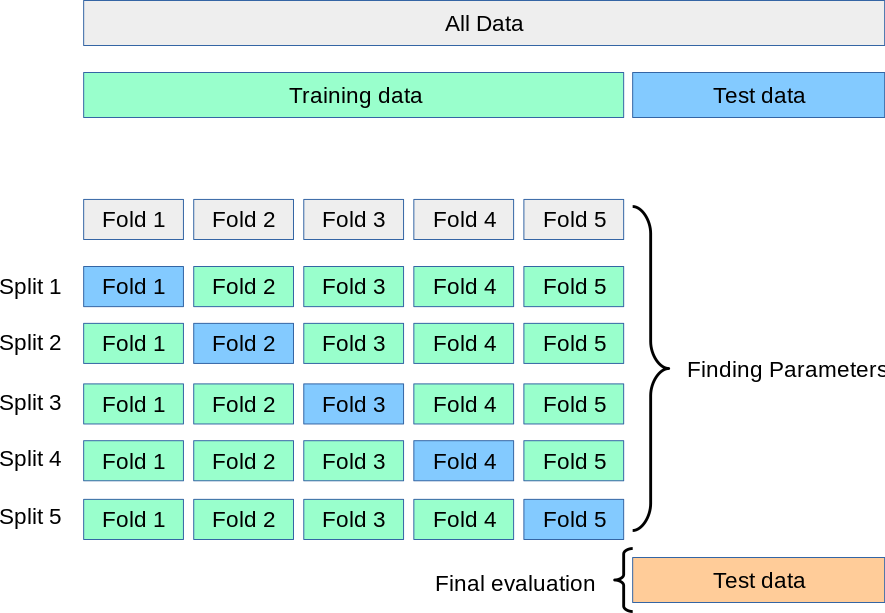

```python
import numpy as np
from sklearn.model_selection import train_test_split
from sklearn import datasets
from sklearn import svm

X, y = datasets.load_iris(return_X_y=True)
X.shape, y.shape
```

```
## ((150, 4), (150,))
```

```python
X_train, X_test, y_train, y_test = train_test_split(
    X, y, test_size=0.4, random_state=0)

X_train.shape, y_train.shape
```

```
## ((90, 4), (90,))
```

```python
X_test.shape, y_test.shape
```

```
## ((60, 4), (60,))
```

```python
clf = svm.SVC(kernel='linear', C=1).fit(X_train, y_train)
clf.score(X_test, y_test)
```

```
## 0.9666666666666667
```

```python
from sklearn.model_selection import cross_val_score
clf = svm.SVC(kernel='linear', C=1)
scores = cross_val_score(clf, X, y, cv=5)
scores
```

```
## array([0.96666667, 1.        , 0.96666667, 0.96666667, 1.        ])
```

```python
print("Accuracy: %0.2f (+/- %0.2f)" % (scores.mean(), scores.std() * 2))
```

```
## Accuracy: 0.98 (+/- 0.03)
```

```python
from sklearn import metrics
scores = cross_val_score(
    clf, X, y, cv=5, scoring='f1_macro')
scores
```

```
## array([0.96658312, 1.        , 0.96658312, 0.96658312, 1.        ])
```

```python
from sklearn.model_selection import ShuffleSplit
n_samples = X.shape[0]
cv = ShuffleSplit(n_splits=5, test_size=0.3, random_state=0)
cross_val_score(clf, X, y, cv=cv)
```

```
## array([0.97777778, 0.97777778, 1.        , 0.95555556, 1.        ])
```

## Visualizing missing values

```r
head(airquality)
```

```
##   Ozone Solar.R Wind Temp Month Day
## 1    41     190  7.4   67     5   1
## 2    36     118  8.0   72     5   2
## 3    12     149 12.6   74     5   3
## 4    18     313 11.5   62     5   4
## 5    NA      NA 14.3   56     5   5
## 6    28      NA 14.9   66     5   6
```

```r
# Count missing vals in entire dataset
sum(is.na(airquality))
```

```
## [1] 44
```

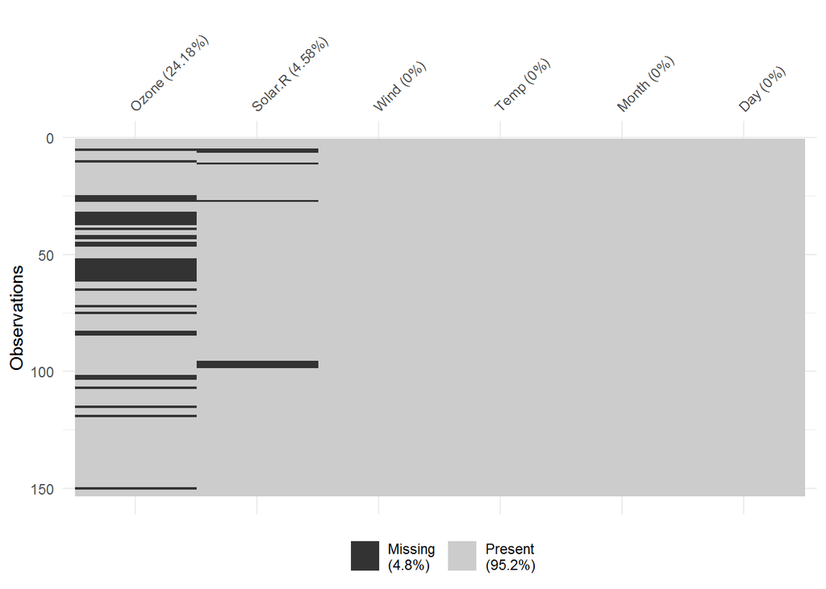

```r
library(visdat)
vis_miss(airquality)
```

## Investigating missingness

```r
airquality %>%
  mutate(miss_ozone = is.na(Ozone)) %>%
  group_by(miss_ozone) %>%
  summarize_all(median, na.rm = TRUE)
```

```
## # A tibble: 2 x 7
##   miss_ozone Ozone Solar.R  Wind  Temp Month   Day
##   <lgl>      <dbl>   <int> <dbl> <dbl> <dbl> <dbl>
## 1 FALSE       31.5     207   9.7    79     7    16
## 2 TRUE        NA       194   9.7    79     6    15
```

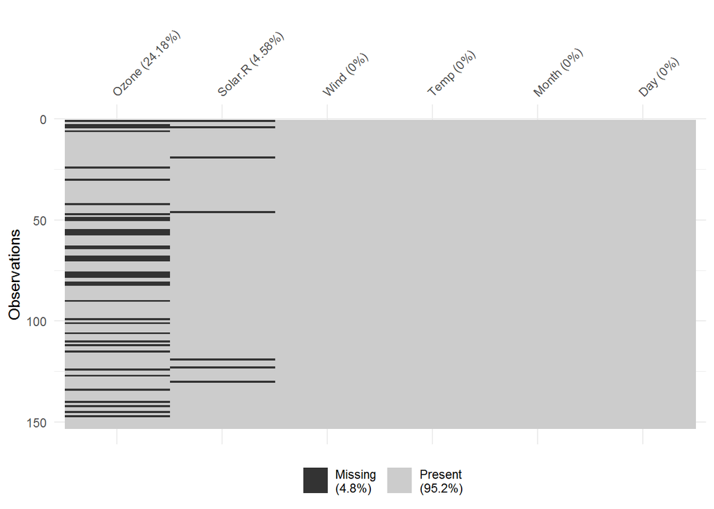

```r
airquality %>%
  arrange(Temp) %>%
  vis_miss()
```

## Data scaling

When a variable in a dataset is on a larger scale than other variables it may disproportionately influence the resulting distance calculated between the observations.

We will leverage the scale() function which by default centers & scales the column features.

The dataset variables are the following: * Girth - tree diameter in inches * Height - tree height in inches

```r
three_trees = data.frame(Girth = c(8.3, 8.6, 10.5), Height = c(840, 780, 864))
three_trees
```

```
##   Girth Height
## 1   8.3    840
## 2   8.6    780
## 3  10.5    864
```

```r
dist_trees <- dist(three_trees)

# Scale three trees & calculate the distance
scaled_three_trees <- scale(three_trees)
dist_scaled_trees <- dist(scaled_three_trees)

# Output the results of both Matrices
print('Without Scaling')
```

```
## [1] "Without Scaling"
```

```r
dist_trees
```

```
##          1        2
## 2 60.00075
## 3 24.10062 84.02149
```

```r
print('With Scaling')
```

```
## [1] "With Scaling"
```

```r
dist_scaled_trees
```

```
##          1        2
## 2 1.409365
## 3 1.925659 2.511082
```

## Linear regression evaluation

### R-Squred

```r
library(fst)
taiwan_real_estate <- read_fst("data/taiwan_real_estate.fst")
head(taiwan_real_estate)
```

```
##   dist_to_mrt_m n_convenience house_age_years price_twd_msq
## 1      84.87882            10        30 to 45     11.467474
## 2     306.59470             9        15 to 30     12.768533
## 3     561.98450             5         0 to 15     14.311649
## 4     561.98450             5         0 to 15     16.580938
## 5     390.56840             5         0 to 15     13.040847
## 6    2175.03000             3         0 to 15      9.712557
```

Here we fil a linear regression model for predicting price_twd_msq based on n_convenience usning taiwan_real_estate dataset.

```r
lm_model <- lm(formula = price_twd_msq ~ n_convenience, data = taiwan_real_estate)
```

The summary of the linear regression model:

it shows the r-squred value: (“Multiple R-Squared”)

```r
summary(lm_model)
```

```
##
## Call:
## lm(formula = price_twd_msq ~ n_convenience, data = taiwan_real_estate)
##
## Residuals:
##      Min       1Q   Median       3Q      Max
## -10.7132  -2.2213  -0.5409   1.8105  26.5299
##
## Coefficients:
##               Estimate Std. Error t value Pr(>|t|)
## (Intercept)    8.22424    0.28500   28.86   <2e-16 ***
## n_convenience  0.79808    0.05653   14.12   <2e-16 ***
## ---
## Signif. codes:  0 '***' 0.001 '**' 0.01 '*' 0.05 '.' 0.1 ' ' 1
##
## Residual standard error: 3.384 on 412 degrees of freedom
## Multiple R-squared:  0.326,  Adjusted R-squared:  0.3244
## F-statistic: 199.3 on 1 and 412 DF,  p-value: < 2.2e-16
```

```r
library(broom)
library(dplyr)
lm_model %>%
    glance()
```

```
## # A tibble: 1 x 11
##   r.squared adj.r.squared sigma statistic  p.value    df logLik   AIC   BIC
##       <dbl>         <dbl> <dbl>     <dbl>    <dbl> <int>  <dbl> <dbl> <dbl>
## 1     0.326         0.324  3.38      199. 3.41e-37     2 -1091. 2188. 2200.
## # ... with 2 more variables: deviance <dbl>, df.residual <int>
```

```r
lm_model %>%
    glance() %>%
    pull(r.squared)
```

```
## [1] 0.3260466
```

It’s just correlation squared

```r
taiwan_real_estate %>%
  summarize(
    coeff_determination = cor(price_twd_msq, n_convenience) ^ 2
  )
```

```
##   coeff_determination
## 1           0.3260466
```

### Residual standard error (RSE)

a “typical” difference between a prediction and an observed response It has the same unit as the response variable.

The summary of the linear regression model:

it shows the Residual standard error (RSE) value: “Residual standard error”

```r
summary(lm_model)
```

```
##
## Call:
## lm(formula = price_twd_msq ~ n_convenience, data = taiwan_real_estate)
##
## Residuals:
##      Min       1Q   Median       3Q      Max
## -10.7132  -2.2213  -0.5409   1.8105  26.5299
##
## Coefficients:
##               Estimate Std. Error t value Pr(>|t|)
## (Intercept)    8.22424    0.28500   28.86   <2e-16 ***
## n_convenience  0.79808    0.05653   14.12   <2e-16 ***
## ---
## Signif. codes:  0 '***' 0.001 '**' 0.01 '*' 0.05 '.' 0.1 ' ' 1
##
## Residual standard error: 3.384 on 412 degrees of freedom
## Multiple R-squared:  0.326,  Adjusted R-squared:  0.3244
## F-statistic: 199.3 on 1 and 412 DF,  p-value: < 2.2e-16
```

```r
library(broom)
library(dplyr)
lm_model %>%
    glance()
```

```
## # A tibble: 1 x 11
##   r.squared adj.r.squared sigma statistic  p.value    df logLik   AIC   BIC
##       <dbl>         <dbl> <dbl>     <dbl>    <dbl> <int>  <dbl> <dbl> <dbl>
## 1     0.326         0.324  3.38      199. 3.41e-37     2 -1091. 2188. 2200.
## # ... with 2 more variables: deviance <dbl>, df.residual <int>
```

```r
lm_model %>%
    glance() %>%
    pull(sigma)
```

```
## [1] 3.383888
```

Calculating RSE: residuals squared

```r
taiwan_real_estate %>%
  mutate(
    residuals_sq = residuals(lm_model) ^ 2
  )
```

```
##     dist_to_mrt_m n_convenience house_age_years price_twd_msq residuals_sq
## 1        84.87882            10        30 to 45     11.467474 2.244449e+01
## 2       306.59470             9        15 to 30     12.768533 6.961273e+00
## 3       561.98450             5         0 to 15     14.311649 4.397463e+00
## 4       561.98450             5         0 to 15     16.580938 1.906459e+01
## 5       390.56840             5         0 to 15     13.040847 6.826249e-01
## 6      2175.03000             3         0 to 15      9.712557 8.206908e-01
## 7       623.47310             7        30 to 45     12.193646 2.615172e+00
## 8       287.60250             6        15 to 30     14.130106 1.248561e+00
## 9      5512.03800             1        30 to 45      5.688351 1.111533e+01
## 10     1783.18000             3        15 to 30      6.686838 1.545778e+01
## 11      405.21340             1        30 to 45     12.526475 1.227912e+01
## 12       90.45606             9         0 to 15     17.579425 4.719627e+00
## 13      492.23130             5         0 to 15     11.891074 1.046923e-01
## 14     2469.64500             4        15 to 30      7.201210 1.776914e+01
```

[output cut: 400 more lines]

Calculating RSE: sum of residuals squared

```r
taiwan_real_estate %>%
  mutate(
    residuals_sq = residuals(lm_model) ^ 2
  ) %>%
  summarize(
    resid_sum_of_sq = sum(residuals_sq)
  )
```

```
##   resid_sum_of_sq
## 1        4717.686
```

Calculating RSE: degrees of freedom Degrees of freedom equals the number of observations minus the number of model coef

```r
taiwan_real_estate %>%
  mutate(
    residuals_sq = residuals(lm_model) ^ 2
  ) %>%
  summarize(
    resid_sum_of_sq = sum(residuals_sq),
    deg_freedom = n() - 2
  )
```

```
##   resid_sum_of_sq deg_freedom
## 1        4717.686         412
```

Calculating RSE: square root of ratio

```r
taiwan_real_estate %>%
  mutate(
    residuals_sq = residuals(lm_model) ^ 2
  ) %>%
  summarize(
    resid_sum_of_sq = sum(residuals_sq),
    deg_freedom = n() - 2,
    rse = sqrt(resid_sum_of_sq / deg_freedom)
  )
```

```
##   resid_sum_of_sq deg_freedom      rse
## 1        4717.686         412 3.383888
```

Interpreting RSE

lm_model has an RSE of 3.38.

**Residual standard error**

```r
taiwan_real_estate %>%
  mutate(
    residuals_sq = residuals(lm_model) ^ 2
  ) %>%
  summarize(
    resid_sum_of_sq = sum(residuals_sq),
    deg_freedom = n() - 2,
    rse = sqrt(resid_sum_of_sq / deg_freedom)
  )
```

```
##   resid_sum_of_sq deg_freedom      rse
## 1        4717.686         412 3.383888
```

**Root-mean-square error**

```r
taiwan_real_estate %>%
  mutate(
    residuals_sq = residuals(lm_model) ^ 2
  ) %>%
  summarize(
    resid_sum_of_sq = sum(residuals_sq),
    n_obs = n(),
    rmse = sqrt(resid_sum_of_sq / n_obs)
  )
```

```
##   resid_sum_of_sq n_obs     rmse
## 1        4717.686   414 3.375704
```

## fct_collapse

Collapse factor levels into manually defined groups

The wine data, shown below, contains information about various wines stocked by an online retailer. All appropriate variables are already stored as categorical variables, however you have now decided that it would improve your analysis if wine types were encoded as:

- white: white and sparkling
- red: red

```r
wine <- data.frame(
    id = c(21, 95, 69, 31, 76),
    style = as.factor(c("gavi", "blanc de blanc", "riesling", "alvarinho", "valpolicella")),
    type = as.factor(c("white", "sparkling", "white", "white", "red")),
    country = as.factor(c("italy", "france", "germany", "portugal", "italy")),
    price = c(13.6, NA, 17.0, 19.0, 19.4),
    rating = c(NA, 3.8, 4, 4.2, 4.2)
)
wine
```

```
##   id          style      type  country price rating
## 1 21           gavi     white    italy  13.6     NA
## 2 95 blanc de blanc sparkling   france    NA    3.8
## 3 69       riesling     white  germany  17.0    4.0
## 4 31      alvarinho     white portugal  19.0    4.2
## 5 76   valpolicella       red    italy  19.4    4.2
```

```r
library(tidyverse)
library(forcats)
wine
```

```
##   id          style      type  country price rating
## 1 21           gavi     white    italy  13.6     NA
## 2 95 blanc de blanc sparkling   france    NA    3.8
## 3 69       riesling     white  germany  17.0    4.0
## 4 31      alvarinho     white portugal  19.0    4.2
## 5 76   valpolicella       red    italy  19.4    4.2
```

```r
wine %>%
  mutate(type = fct_collapse(type,
                "red" = "red",
                "white" = c("white", "sparkling")))
```

```
##   id          style  type  country price rating
## 1 21           gavi white    italy  13.6     NA
## 2 95 blanc de blanc white   france    NA    3.8
## 3 69       riesling white  germany  17.0    4.0
## 4 31      alvarinho white portugal  19.0    4.2
## 5 76   valpolicella   red    italy  19.4    4.2
```

```r
wine %>%
    count(type)
```

```
##        type n
## 1       red 1
## 2 sparkling 1
## 3     white 3
```

```r
wine %>%
  mutate(type = fct_collapse(type,
                "red" = "red",
                "white" = c("white", "sparkling"))) %>%
  count(type)
```

```
##    type n
## 1   red 1
## 2 white 4
```

## Spread

Spread A Key-Value Pair Across Multiple Columns.

Restructure the following data, df, so that there is one column for each year.

```r
df <- data.frame(
    country = c("Afghanistan", "Albania", "Algeria", "Afghanistan", "Albania", "Algeria"),
    year = c("Y1980", "Y1980", "Y1980", "Y1981", "Y1981", "Y1981"),
    bmi = c(21.48678, 25.22533, 22.25703, 21.46552, 25.23981, 22.34745)
)

df
```

```
##       country  year      bmi
## 1 Afghanistan Y1980 21.48678
## 2     Albania Y1980 25.22533
## 3     Algeria Y1980 22.25703
## 4 Afghanistan Y1981 21.46552
## 5     Albania Y1981 25.23981
## 6     Algeria Y1981 22.34745
```

```r
spread(df, year, bmi)
```

```
##       country    Y1980    Y1981
## 1 Afghanistan 21.48678 21.46552
## 2     Albania 25.22533 25.23981
## 3     Algeria 22.25703 22.34745
```

## Gather

Gather Columns Into Key-Value Pairs.

Change the structure of the data df, shown below, so that there is a column to represent the year and a column to represent the bmi values.

```r
df2 <- spread(df, year, bmi)
df2
```

```
##       country    Y1980    Y1981
## 1 Afghanistan 21.48678 21.46552
## 2     Albania 25.22533 25.23981
## 3     Algeria 22.25703 22.34745
```

```r
gather(df2, year, bmi, -country)
```

```
##       country  year      bmi
## 1 Afghanistan Y1980 21.48678
## 2     Albania Y1980 25.22533
## 3     Algeria Y1980 22.25703
## 4 Afghanistan Y1981 21.46552
## 5     Albania Y1981 25.23981
## 6     Algeria Y1981 22.34745
```

## Data visualization withh ggplot2

### The penguins data from palmerpenguins packages

We’ll be using the penguins data from the palmerpenguins package. You can read about the variables in the data frame [here](https://allisonhorst.github.io/palmerpenguins/reference/penguins.html) and a quick peek is provided below.

```r
library(tidyverse)
library(palmerpenguins)
```

```r
glimpse(penguins)
```

```
## Rows: 344
## Columns: 8
## $ species           <fct> Adelie, Adelie, Adelie, Adelie, Adelie, Adelie, A...
## $ island            <fct> Torgersen, Torgersen, Torgersen, Torgersen, Torge...
## $ bill_length_mm    <dbl> 39.1, 39.5, 40.3, NA, 36.7, 39.3, 38.9, 39.2, 34....
## $ bill_depth_mm     <dbl> 18.7, 17.4, 18.0, NA, 19.3, 20.6, 17.8, 19.6, 18....
## $ flipper_length_mm <int> 181, 186, 195, NA, 193, 190, 181, 195, 193, 190, ...
## $ body_mass_g       <int> 3750, 3800, 3250, NA, 3450, 3650, 3625, 4675, 347...
## $ sex               <fct> male, female, female, NA, female, male, female, m...
## $ year              <int> 2007, 2007, 2007, 2007, 2007, 2007, 2007, 2007, 2...
```

### Making a single box

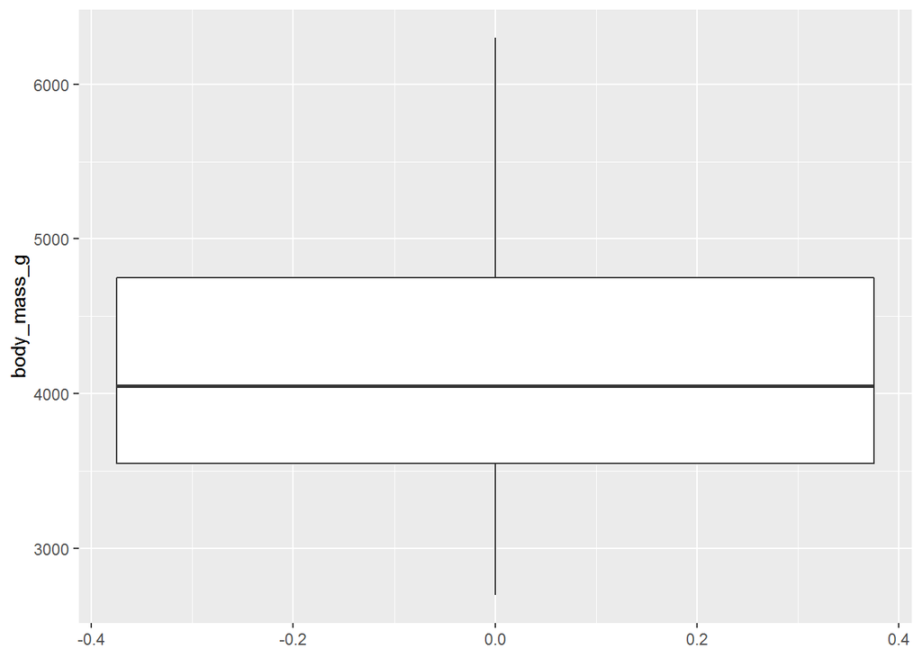

```r
ggplot(penguins, aes(y = body_mass_g)) +
  geom_boxplot()
```

### No more coord_flip()

Horizontal bar plots can be really useful, especially for categorical data whose levels have long names that overlap if placed on the x-axis. Previously, making horizontal bar plots required mapping the variable to be plotted to the x aesthetic and then applying a coord_flip() layer to flip the axes, e.g.

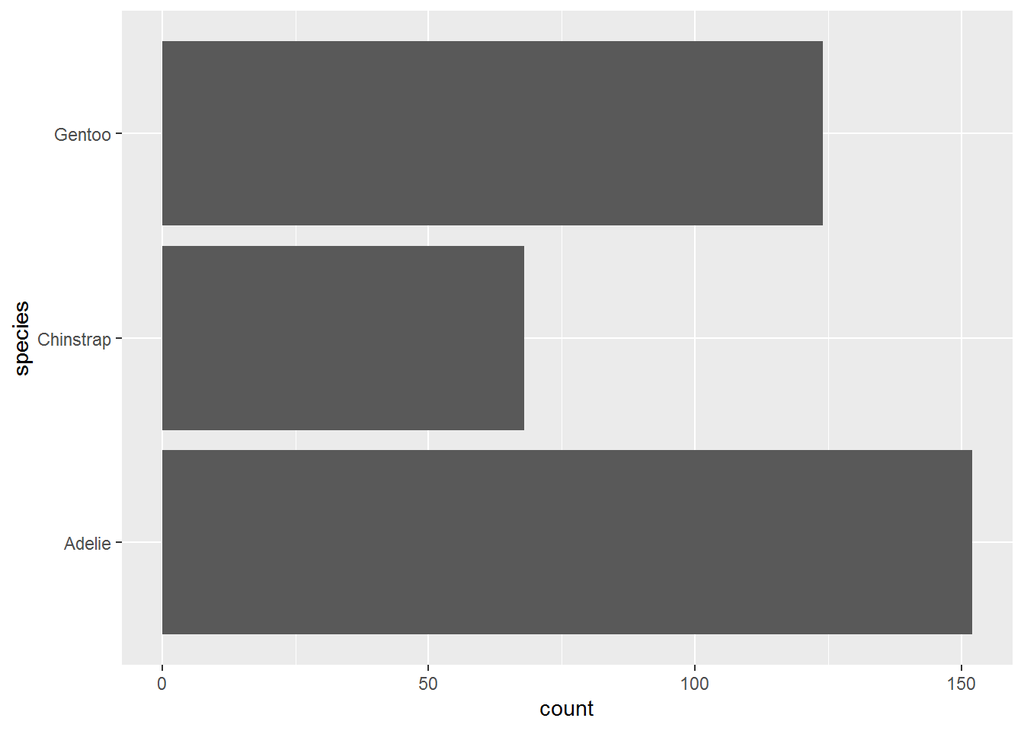

```r
ggplot(penguins, aes(x = species)) +
  geom_bar() +
  coord_flip()
```

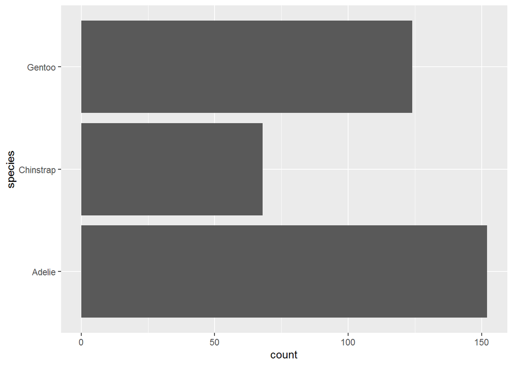

```r
ggplot(penguins, aes(y = species)) +
  geom_bar()
```

### Leverage scales and forcats

One of the biggest strengths of ggplot2 is that it has fantastic defaults and your plots look pretty good without trying hard. This is very attractive especially for teaching introductory audiences when you just want to focus on the basics. However, when teaching data visualisation (even in the simplest sense) it is important to discuss data visualisation good practices, e.g. present data in ascending/descending order, label axes in a way that matches your narrative, etc. Packages like [scales](http://scales.r-lib.org/) and [forcats](https://forcats.tidyverse.org/) are incredibly helpful for implementing these small but impactful improvements to visualisations.

Suppose we want to plot the percentage distribution of different species of penguins. We can first calculate these percentages in a dplyr pipeline.

```r
penguins %>%
  count(species) %>%
  mutate(prop = n / sum(n))
```

```
## # A tibble: 3 x 3
##   species       n  prop
##   <fct>     <int> <dbl>
## 1 Adelie      152 0.442
## 2 Chinstrap    68 0.198
## 3 Gentoo      124 0.360
```

We can then feed the result to the ggplot() function to be represented using geom_col().

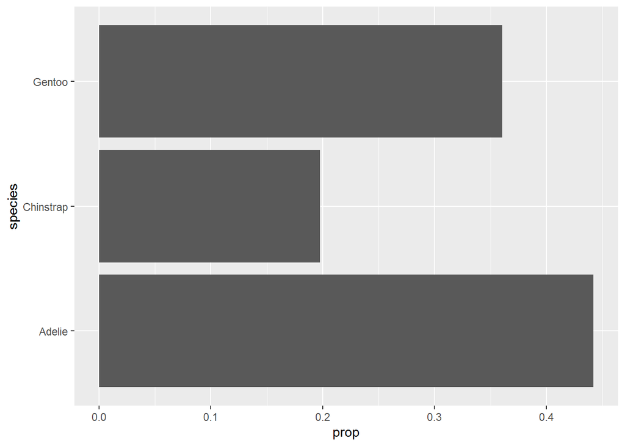

```r
penguins %>%
  count(species) %>%
  mutate(prop = n / sum(n)) %>%
  ggplot(aes(x = prop, y = species)) +
  geom_col()
```

First, let’s reorder the bars in descending order, with the penguin species with the highest proportion on top. We use fct_reorder() function from the forcats package for this. We can read fct_reorder(species, prop) as “reorder the levels of species based on the values of prop”.

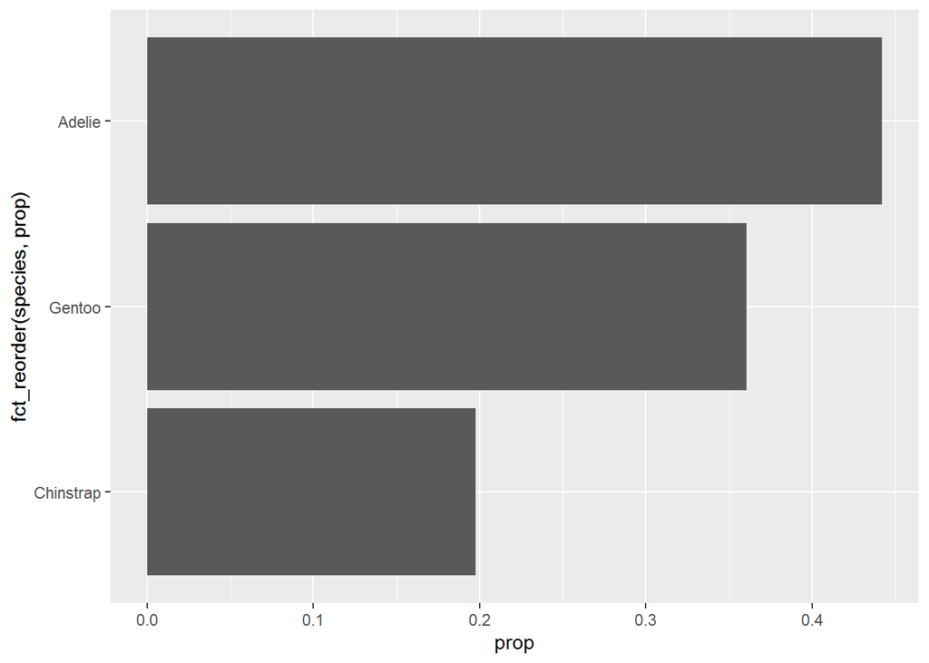

```r
penguins %>%
  count(species) %>%
  mutate(prop = n / sum(n)) %>%
  ggplot(aes(x = prop, y = fct_reorder(species, prop))) +
  geom_col()
```

The forcats package contains a variety of functions starting with the prefix fct_ that operate on factor levels. Perhaps unsurprisingly, they’re named pretty intuitively (at least for English speakers). (Side note: After fct_reorder(), my favourite function for improving visualisations of messy survey data with factors with many levels is fct_lump().)

Next, let’s think about how we would interpret this visualisation. I would probably say something like “Adelie penguins make up over 40% of the sample, followed by Gentoo penguins at roughly over 35%, and Chinstrap penguins make up the remaining 20%”. But the x-axis is showing proportions instead of percentages.

The scales package offers a variety of functions, starting with the prefix label_* that help with this sort of task.

```r
library(scales)
```

The function we want here is label_percent(). We can also specify the number of decimal places to show with the accuracy argument.

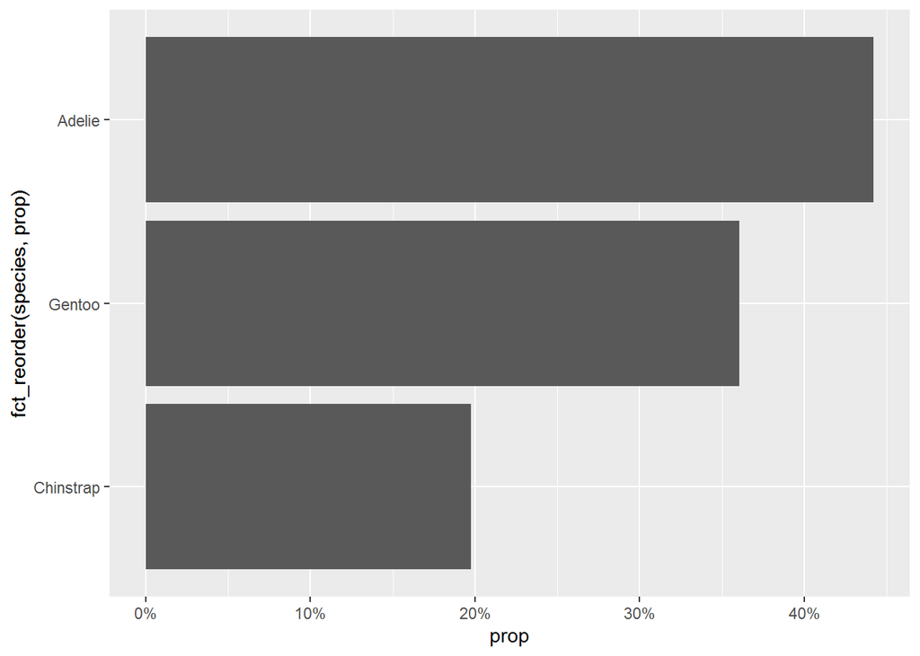

```r
penguins %>%
  count(species) %>%
  mutate(prop = n / sum(n)) %>%
  ggplot(aes(x = prop, y = fct_reorder(species, prop))) +
  geom_col() +
  scale_x_continuous(labels = label_percent(accuracy = 1))
```

And finally, let’s fix up the axis labels.

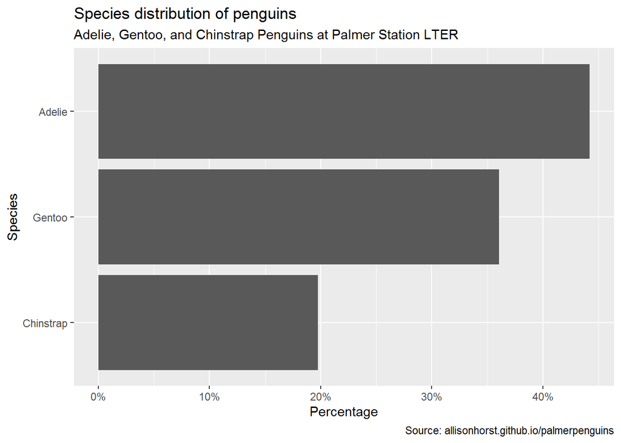

```r
penguins %>%
  count(species) %>%
  mutate(prop = n / sum(n)) %>%
  ggplot(aes(x = prop, y = fct_reorder(species, prop))) +
  geom_col() +
  scale_x_continuous(labels = label_percent(accuracy = 1)) +
  labs(
    x = "Percentage",
    y = "Species",
    title = "Species distribution of penguins",
    subtitle = "Adelie, Gentoo, and Chinstrap Penguins at Palmer Station LTER",
    caption = "Source: allisonhorst.github.io/palmerpenguins"
  )
```

## tidyverse

*The tidyverse is an opinionated collection of R packages designed for data science. All packages share an underlying design philosophy, grammar, and data structures.* [Source](https://tidyverse.org/)

If you’re a tidyverse user and/or an avid reader of this blog, you probably already know this. But how about your students? Do these words mean anything to your students the first time they hear them? How do you introduce your students to the tidyverse, especially if they are also new to R?

Start with the core packages Start with the core packages, by briefly stating the primary purpose of each, in the order that students will encounter them in your course, e.g.

- **ggplot2**: data visualisation
- **dplyr**: data wrangling
- **readr**: reading data
- **tibble**: modern data frames
- **stringr**: string manipulation
- **forcats**: dealing with factors
- **tidyr**: data tidying
- **purrr**: functional programming

This is the order I recommend and the order that follows the curriculum outlined in Data Science in a Box. Start with visualisation (ggplot2) and delay introducing functional programming (purrr) until later. (More on why and how to delay introducing purrr in the last post in the series!)

The important thing to note here is that I don’t recommend bringing up the non-core packages, i.e. those installed with the tidyverse, but not loaded along with it. Regardless of the level at which you’re teaching, chances are you won’t be using all of those packages in a single course. I recommend introducing other packages used in your course (whether they are a part of the tidyverse or not) as they become relevant to the topic you’re covering, and simply highlight that the packages from the wider tidyverse share the design philosophy, grammar, and data structures as the core packages, e.g. the rvest package for web scraping plays nicely with pipes.